# 2.0 RNA-seq pipeline comparison — OLD vs NEW counts (A549 + HT1080)

# Why this notebook exists

The HT1080 and A549 cell lines were each sequenced once, but the FASTQ files have been **re-quantified through two different upstream pipelines** at different points in the project. Per-cell-line analyses (2.1.1 A549, 2.2.1 HT1080) all use the **NEW** counts; older reports (in `data/RNAseq/AUG_13_2025_LOY_A549_HT1080/`) use the **OLD** counts. This notebook asks: **how comparable are the two count tables, and would the biological conclusions change if we’d kept the OLD counts?**

## Pipeline difference summary

| Field | OLD pipeline | NEW pipeline |
| --- | --- | --- |
| Counts dir | `data/RNAseq/AUG_13_2025_LOY_A549_HT1080/counts/` | `projects/RNAseq/counts/AUG_2025_<cell>_LOY/` |
| Aligner | HISAT2 | STAR two-pass |
| Reference annotation | GENCODE v47 (`chr_patch_hapl_scaff`) | GENCODE v49 (primary assembly) |
| featureCounts | v2.0.1 | v2.1.1 |
| Sample composition | identical (9 HT1080 + 11 A549) | identical |

Same biological samples; same FASTQs; different aligner + reference + quantifier version. Differences between the two count tables are therefore **technical** — they tell us how much downstream interpretation is sensitive to the upstream pipeline choice.

# 1. Setup

# 2. Load count tables

```
## HT1080 OLD: 86402 genes x 9 samples
```

```
## HT1080 NEW: 78899 genes x 9 samples
```

```
## A549  OLD: 86402 genes x 11 samples
```

```
## A549  NEW: 78899 genes x 11 samples
```

# 3. Library sizes by pipeline

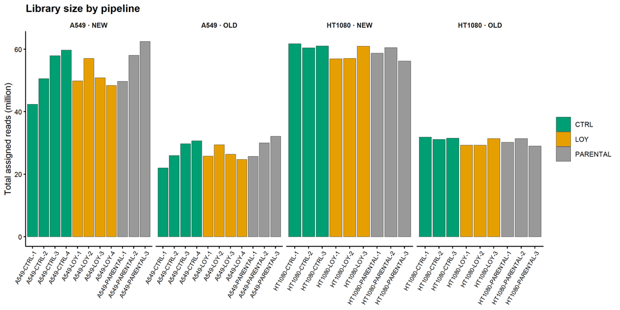

```
## Saved: libsize_by_pipeline.(png|pdf)
```

Per-cell-line library size: OLD vs NEW

| cell | mean_OLD_M | mean_NEW_M | mean_rel_diff |
| --- | --- | --- | --- |
| A549 | 27.526 | 53.384 | 0.939 |
| HT1080 | 30.604 | 59.311 | 0.938 |

# 4. Gene-ID harmonization + filtering

The OLD pipeline annotated with GENCODE v47, NEW with v49. Both produce Ensembl IDs like `ENSG00000123456.18` (with version suffix). The integer ENSG accession is stable across versions; the suffix changes when the gene’s annotation is updated. We harmonize by stripping the suffix and intersecting on the accession.

```
## --- HT1080 ----------------------------------------
```

```
##   OLD-unique ENSG: 7527
```

```
##   NEW-unique ENSG: 24
```

```
##   Shared ENSG:     78875
```

```
## --- A549 ------------------------------------------
```

```
##   OLD-unique ENSG: 7527
```

```
##   NEW-unique ENSG: 24
```

```
##   Shared ENSG:     78875
```

## 4.1 Filter + TMM normalize each pipeline independently

```
## HT1080 OLD kept after CPM filter: 17085 genes
```

```
## HT1080 NEW kept after CPM filter: 16366 genes
```

```
## A549   OLD kept after CPM filter: 17623 genes
```

```
## A549   NEW kept after CPM filter: 16801 genes
```

# 5. Per-sample correlation: OLD vs NEW (same sample, two pipelines)

For each biological sample, compute Pearson correlation of logCPM between the OLD and NEW pipelines on the intersection of kept genes.

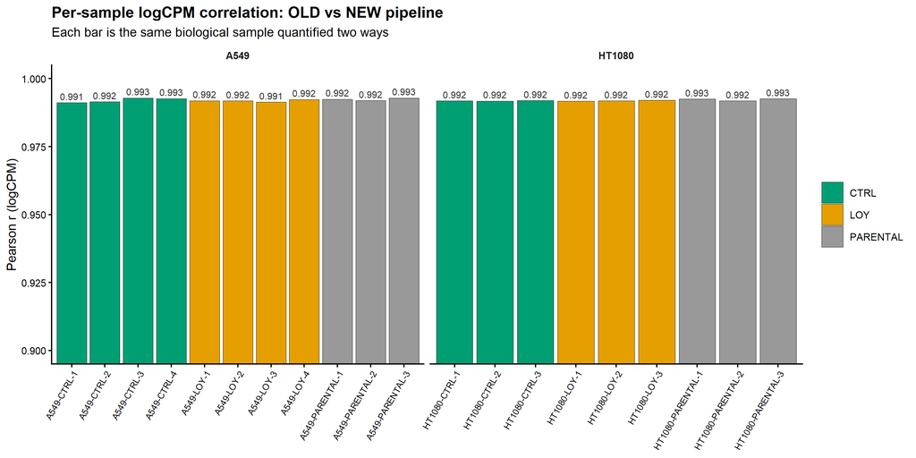

```
## Saved: per_sample_correlation_OLD_vs_NEW.(png|pdf)
```

Cross-pipeline correlation summary

| cell | median_pearson | min_pearson | median_spearman |
| --- | --- | --- | --- |
| A549 | 0.9920 | 0.9912 | 0.9926 |
| HT1080 | 0.9919 | 0.9918 | 0.9922 |

# 6. Per-gene mean expression scatter

For each cell line, mean logCPM per gene across all samples in OLD vs the same gene’s mean across all samples in NEW. Identity line for reference.

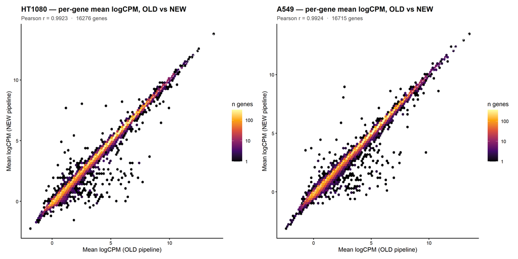

```
## Saved: per_gene_mean_scatter_OLD_vs_NEW.(png|pdf)
```

# 7. Sample correlation heatmap (concatenated OLD + NEW)

Concatenate OLD and NEW logCPM matrices for each cell line and cluster all samples together. Same biological sample under two pipelines should cluster together — and if pipeline effects dominate biology, we’d see OLD vs NEW samples cluster by pipeline instead.

```
## Saved: sample_cor_heatmap_HT1080.(png|pdf)
```

```
## Saved: sample_cor_heatmap_A549.(png|pdf)
```

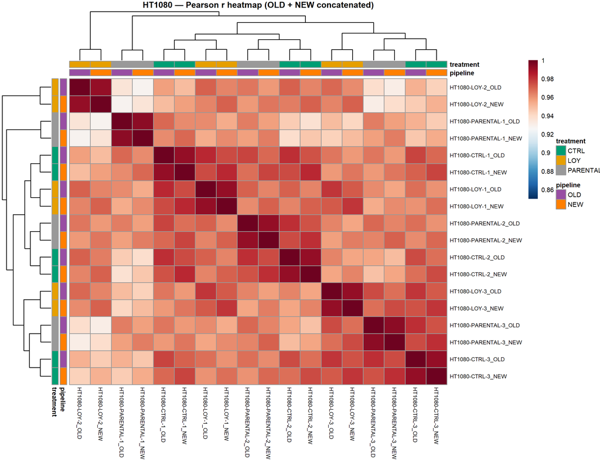

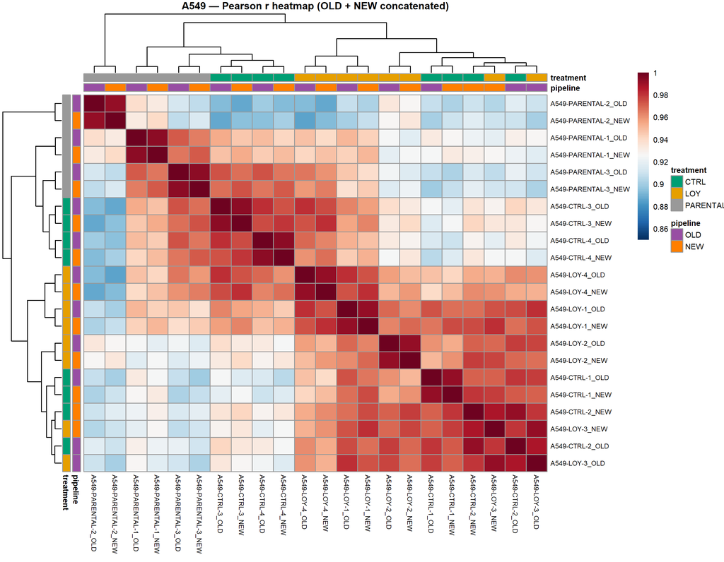

# 8. Differential expression on OLD vs NEW: do the conclusions change?

Three contrasts run on each pipeline’s counts:

1. **Paired** LOY vs sgCTRL (`~ 0 + treatment + passage`) — canonical
2. **Unpaired** LOY vs sgCTRL (`~ 0 + treatment`) — passage drift not modeled
3. **Pooled** LOY vs (PARENTAL + sgCTRL) — combined Y+ baseline, n=6 vs n=3 (HT1080) or n=7 vs n=4 (A549)

Identical underlying biology under both pipelines → high logFC correlation and substantial DEG overlap regardless of which contrast we pick.

DE concordance: OLD vs NEW pipeline across three contrast types

| cell | contrast | sig_OLD | sig_NEW | intersect | jaccard | lfc_r |
| --- | --- | --- | --- | --- | --- | --- |
| HT1080 | LOY vs sgCTRL (paired) | 621 | 579 | 554 | 0.8576 | 0.9908 |
| HT1080 | LOY vs sgCTRL (unpaired) | 65 | 65 | 61 | 0.8841 | 0.9902 |
| HT1080 | LOY vs pooled Y+ | 92 | 84 | 80 | 0.8333 | 0.9912 |
| A549 | LOY vs sgCTRL (paired) | 11 | 10 | 10 | 0.9091 | 0.9854 |
| A549 | LOY vs sgCTRL (unpaired) | 9 | 8 | 8 | 0.8889 | 0.9840 |
| A549 | LOY vs pooled Y+ | 10 | 7 | 7 | 0.7000 | 0.9917 |

## 8.1 Paired LOY vs sgCTRL — concordance

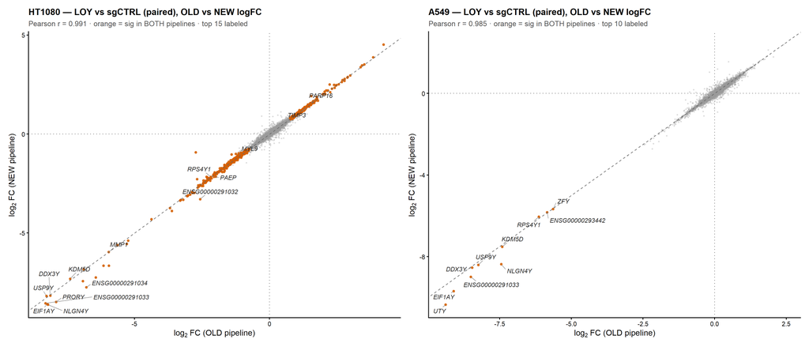

```
## Saved: lfc_concordance_paired.(png|pdf)
```

## 8.2 Unpaired LOY vs sgCTRL — concordance

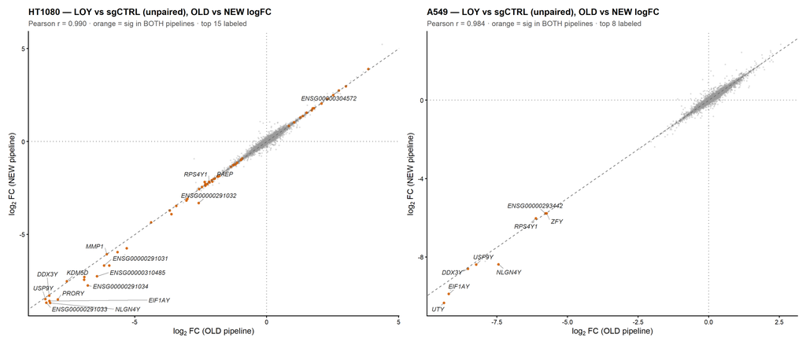

```
## Saved: lfc_concordance_unpaired.(png|pdf)
```

## 8.3 Pooled LOY vs Y+ — concordance

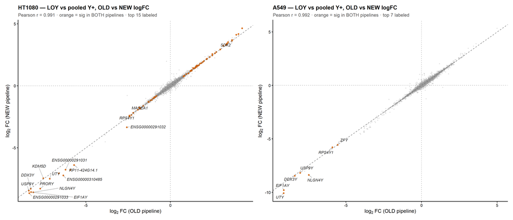

```
## Saved: lfc_concordance_pooled.(png|pdf)
```

# 9. Verdict

```
## HT1080 · LOY vs sgCTRL (paired) CONCORDANT
##   OLD DEGs 621 | NEW DEGs 579 | intersect 554 (Jaccard 0.86) | logFC r = 0.991
##
## HT1080 · LOY vs sgCTRL (unpaired) CONCORDANT
##   OLD DEGs 65 | NEW DEGs 65 | intersect 61 (Jaccard 0.88) | logFC r = 0.990
##
## HT1080 · LOY vs pooled Y+       CONCORDANT
##   OLD DEGs 92 | NEW DEGs 84 | intersect 80 (Jaccard 0.83) | logFC r = 0.991
##
## A549 · LOY vs sgCTRL (paired)   CONCORDANT
##   OLD DEGs 11 | NEW DEGs 10 | intersect 10 (Jaccard 0.91) | logFC r = 0.985
##
## A549 · LOY vs sgCTRL (unpaired) CONCORDANT
##   OLD DEGs 9 | NEW DEGs 8 | intersect 8 (Jaccard 0.89) | logFC r = 0.984
##
## A549 · LOY vs pooled Y+         CONCORDANT
##   OLD DEGs 10 | NEW DEGs 7 | intersect 7 (Jaccard 0.70) | logFC r = 0.992
```